# Course5 reproducible research

## 0. Load data

```r
setwd("X:/Git/Data-Science-Specialization/Course5 reproducible research")
data <- read.csv("activity.csv")
str(data)
```

```
## 'data.frame':    17568 obs. of  3 variables:
##  $ steps   : int  NA NA NA NA NA NA NA NA NA NA ...
##  $ date    : chr  "2012-10-01" "2012-10-01" "2012-10-01" "2012-10-01" ...
##  $ interval: int  0 5 10 15 20 25 30 35 40 45 ...
```

## 1.Calculate the total number of steps taken per day

```r
library(tidyverse)
steps_per_day <- data %>%
  group_by(date) %>%
  summarise(total.per.day = sum(steps))
```

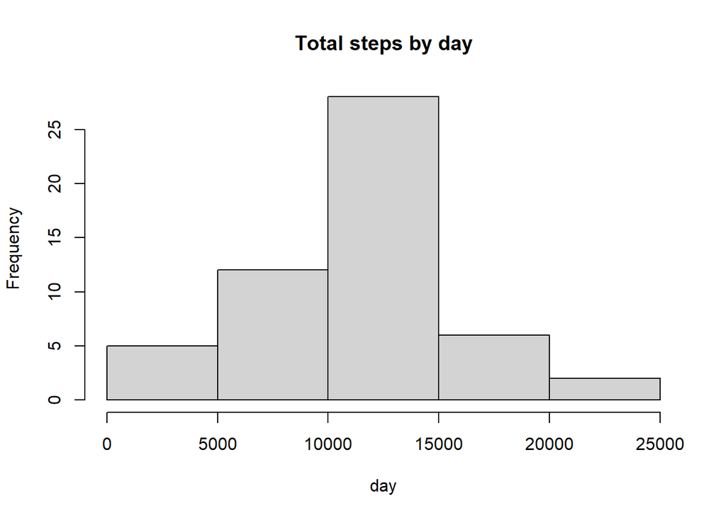

```r
hist(steps_per_day$total.per.day, main = "Total steps by day", xlab = "day")
```

```r
mean_steps_per_day <- mean(steps_per_day$total.per.day, na.rm = TRUE)
median_steps_per_day <- median(steps_per_day$total.per.day, na.rm = TRUE)
```

## 2.What is the average daily activity pattern?

```r
steps_per_interval <- data %>%
  group_by(interval) %>%
  summarise(steps.per.interval = mean(steps, na.rm = TRUE))
```

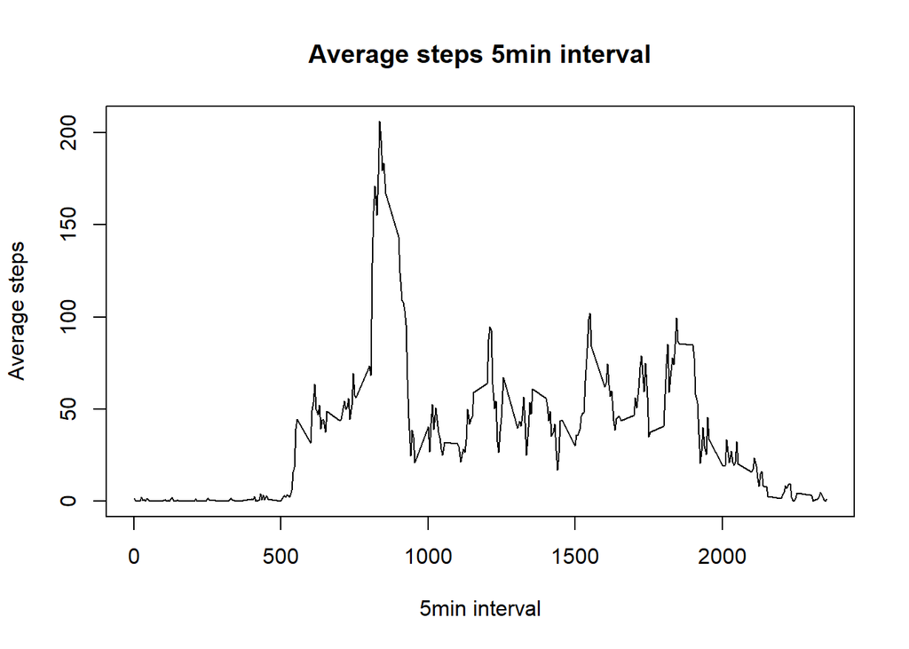

```r
plot(steps_per_interval,type = "l", xlab = "5min interval",
    ylab = "Average steps", main = "Average steps 5min interval")
```

```r
max_steps_interval <- steps_per_interval$interval[which.max(steps_per_interval$steps.per.interval)]
```

At 835 of all 5-minute interval contains the maximum number of steps.

## 3.Imputing missing values

#### 3.1 Calculate and report the total number of missing values in the dataset (i.e. the total number of rows with NAs)

```r
#missing_value <- colSums(is.na(data))
missing_value <- sum(is.na(data))
```

There are 2304 missing values in the dataset.

#### 3.2 Devise a strategy for filling in all of the missing values in the dataset. The strategy does not need to be sophisticated. For example, you could use the mean/median for that day, or the mean for that 5-minute interval, etc.

Solution: use the mean for that 5-minute interval.

```r
#subset rows of data with missing value
data_missing <- data[rowSums(is.na(data)) > 0, ] %>%
  select(date, interval)
#use the mean for that 5-minute interval.
data_missing_filled <- merge(data_missing, steps_per_interval, by = "interval") %>%
  rename(steps = steps.per.interval)
```

#### 3.3Create a new dataset that is equal to the original dataset but with the missing data filled in.

```r
data_ok <- data[rowSums(is.na(data)) == 0, ]
data_full <- rbind(data_ok, data_missing_filled)
```

```r
steps_per_day_new <- data_full %>%
  group_by(date) %>%
  summarise(total.per.day = sum(steps))
```

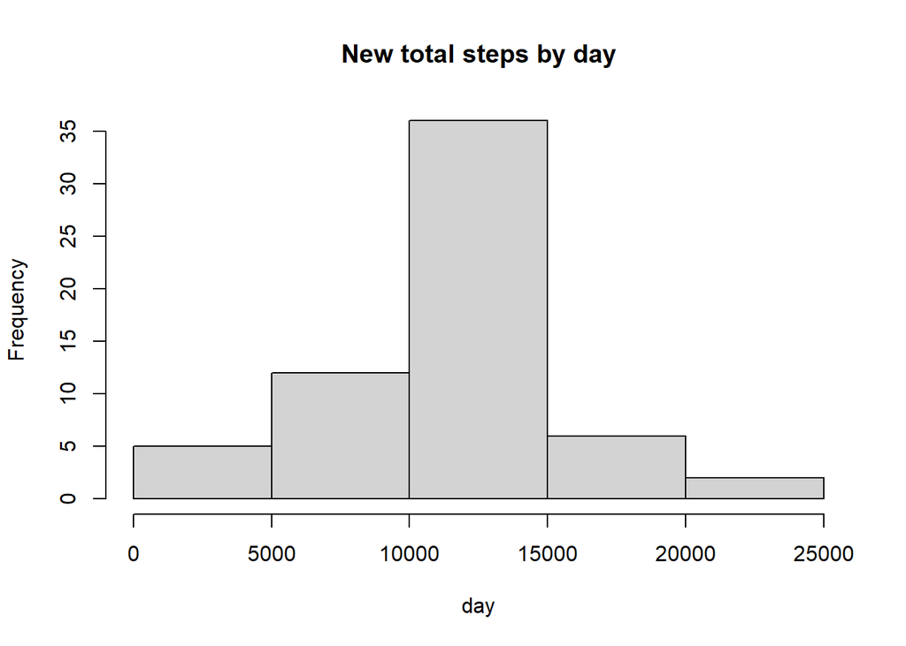

```r
hist(steps_per_day_new$total.per.day, main = "New total steps by day", xlab = "day")
```

```r
mean_steps_per_day_new <- mean(steps_per_day_new$total.per.day, na.rm = TRUE)
median_steps_per_day_new <- median(steps_per_day_new$total.per.day, na.rm = TRUE)
```

## 4 Are there differences in activity patterns between weekdays and weekends?

```r
data_full$day <- weekdays(as.Date(data_full$date))
data_full$weekday <- "weekday"
data_full$weekday[data_full$day == "Sunday" | data_full$day == "Saturday"] <- "weekend"
steps_per_interval_new <- data_full %>%
  group_by(weekday, interval) %>%
  summarise(total.per.interval = mean(steps))
```

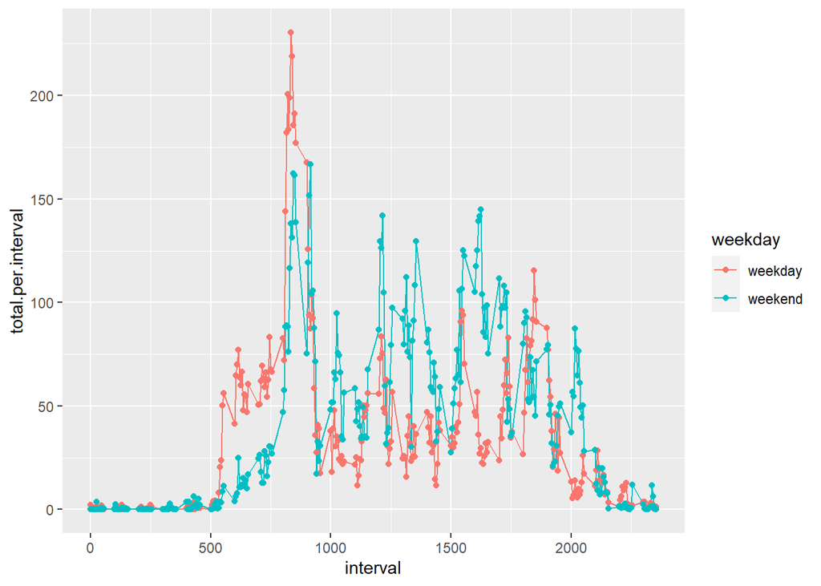

```r
ggplot(steps_per_interval_new, aes(x=interval, y=total.per.interval, group=weekday, color=weekday)) +
  geom_line()+
  geom_point()
```